# Unità 4 Esercizi

Lorenzo Demenia

2023-10-12

I dati contenuti nel file monet.csv riguardano il prezzo di vendita in milioni di dollari di diversi dipinti di Claude Monet. Oltre al prezzo di vendita (price) e l’identificativo numerico del dipinto (id), sono disponibili informazioni circa le dimensioni del dipinto (height e width in pollici), se il dipinto è firmato da Monet o meno (signed) e la casa d’aste in cui il dipinto è stato venduto (house con le tre case identificate da diversi numeri).

1. Si valuti la normalità dei prezzi di vendita dei dipinti.

   ```r
   monet <- read.csv("monet.csv")
   library("car")
   ```

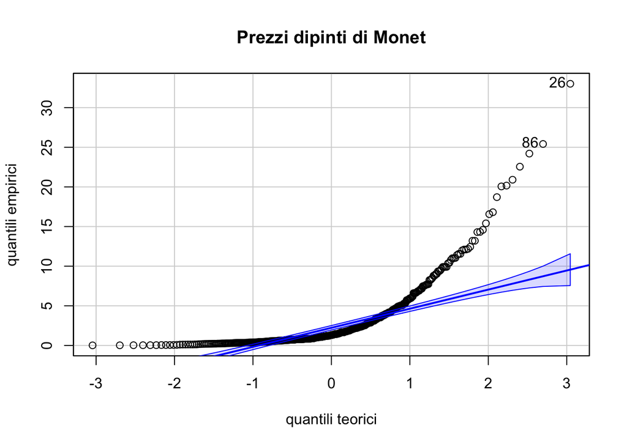

   ```
   ## [1] 26 86
   ```

   ```r
   qqPlot(monet$price, ylab = "quantili empirici", xlab="quantili teorici",
   main="Prezzi dipinti di Monet")
   ```

   Il grafico mostra in modo estremamente chiaro che i prezzi dei dipinti non si possono ritenere nomralmente distribuiti
2. Si valuti la normalità dei prezzi di vendita dei dipinti distinti a seconda se siano stati firmati o no da Claude Monet.

   ```r
       x <- with(monet, price[signed == 1])
       y <- with(monet, price[signed == 0])

       ## Vedimao i grafici quantile-quantile per i due gruppi

       ## il seguente comando divide la finestra grafica in una riga e due
       ## colonne in modo da poter disegnare i due grafici appaiati

       par(mfrow = c(1, 2))
       qqPlot(x, ylab="Quantili empirici", xlab= "Quantili teorici",
       main= "Prezzi dipinti di Monet firmati")
   ```

   ```
   ## [1] 24 73
   ```

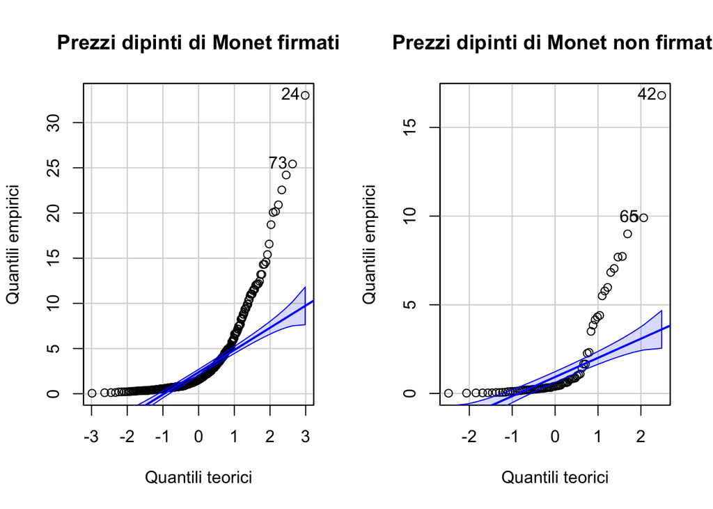

   ```
   ## [1] 42 65
   ```

   ```r
       qqPlot(y, ylab="Quantili empirici", xlab= "Quantili teorici",
       main= "Prezzi dipinti di Monet non firmati")
   ```

   ```r
       ## ritorniamo ad una finestra grafica non divisa, ovvero formata da una
       ## riga e una colonna

       par(mfrow= c(1, 1))
   ```

   Anche i grafici quantile-quantile dei prezzi distinti a seconda della presenza della firmati mostrano un’andamento fortemente non normale
3. Si rivalutino i due punti precedenti dopo aver trasformato i dati su scala logaritmica.

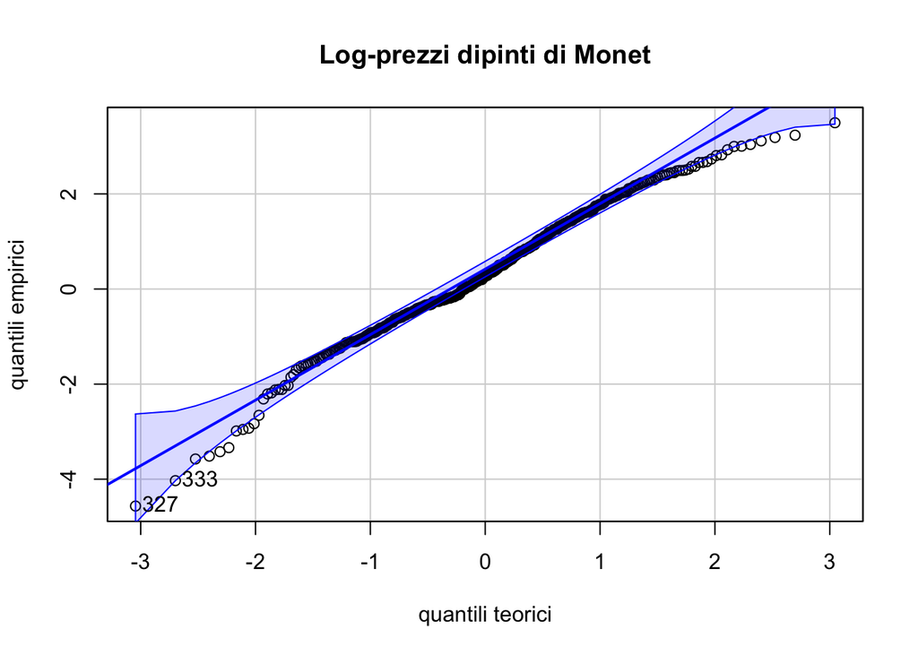

   ```
   ## [1] 327 333
   ```

   ```r
       qqPlot(log(monet$price), ylab = "quantili empirici", xlab ="quantili teorici", main="Log-prezzi dipinti di Monet")
   ```

   La trasfomrazione logaritmica ha decisamente migliorato la situazione sebbene la disposizione dei punti sulle code non sia soddisfacente.

   Infine, vediamo i grafici quantile-quantile dei prezzi a seconda se i dipinti siano firmati o meno:

   ```r
       par(mfrow = c(1, 2))
       qqPlot(log(x), ylab="Quantili empirici", xlab= "Quantili teorici",
       main= "Log-Prezzi dipinti di Monet firmati")
   ```

   ```
   ## [1] 276  24
   ```

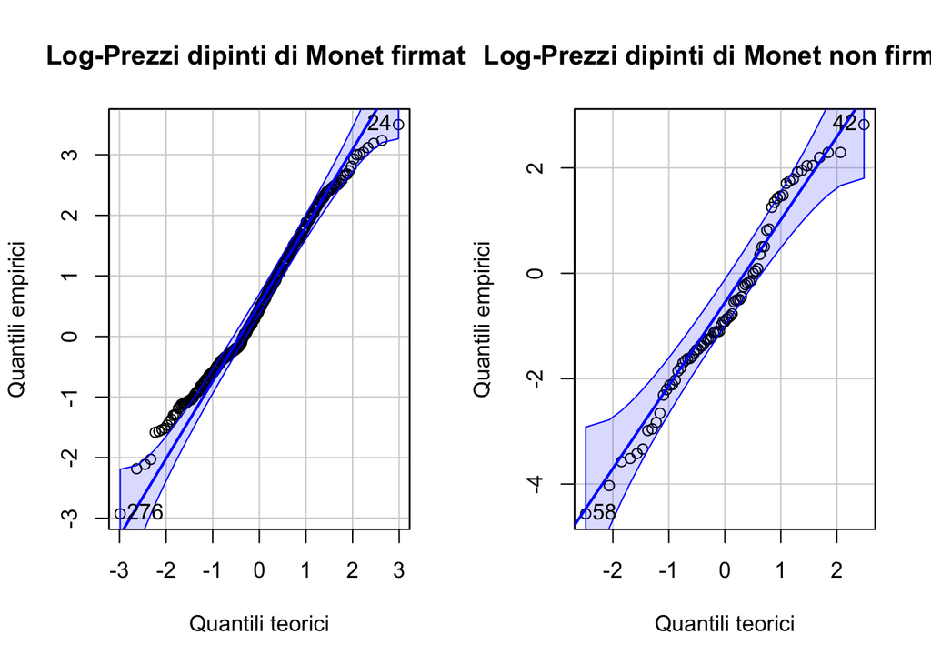

   ```
   ## [1] 58 42
   ```

   ```r
       qqPlot(log(y), ylab="Quantili empirici", xlab= "Quantili teorici",
       main= "Log-Prezzi dipinti di Monet non firmati")
   ```

   ```r
       ## ritorniamo ad una finestra grafica non divisa, ovvero formata da una
       ## riga e una colonna

       par(mfrow= c(1, 1))
   ```

   Il grafico relativo ai dipinti non firmati ci permette di concludere che non possiamo escludere che i prezzi su scala logaritmica siano nomralmente distribuiti, mentre per i dipinti firmati gli andamenti sulle code, e in particolare su quella di sinistra, non sono del tutto soddisfacenti
4. Si valuti se il prezzo di vendita dei dipinti firmati da Claude Monet sia significativa- mente più alto del prezzo di vendita dei dipinti attribuiti a Claude Monet seppur non firmati dal pittore.

   Estraiamo la variabile binaria che indica se un dipinto sia firmato o meno:

   ```r
       firmato <- as.factor(monet$signed)
       levels(firmato) <- c("No", "Sì")
       head(firmato)
   ```

   ```
   ## [1] Sì Sì No Sì Sì Sì
   ## Levels: No Sì
   ```

   Visualizziamo le distribuzioni delle due variabili:

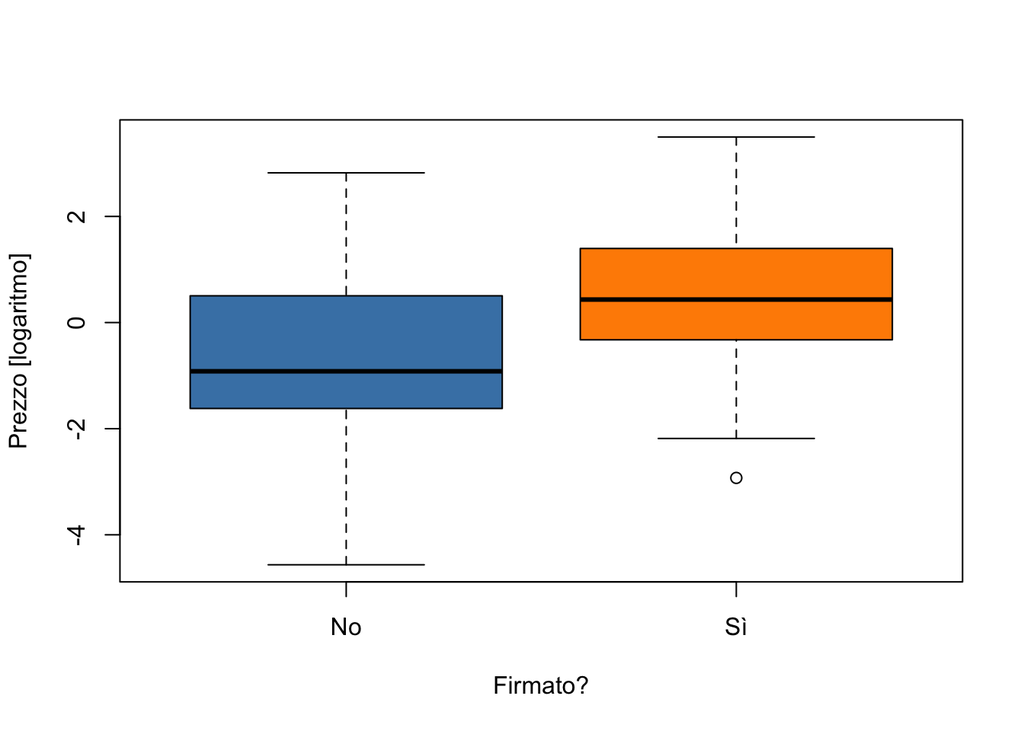

   ```r
       boxplot(log(monet$price)~ firmato, xlab = "Firmato?", ylab = "Prezzo [logaritmo]", col = c("steelblue", "darkorange"))
   ```

   Il grafico mostra che i prezzi di vendira (su scala logaritmica) sono più alti per i dipinti firmati. Valutiamo ora il sistema d’ipotesi per vedere se la differenza osservata è statisticamente significativa.

   Per prima cosa costruiamo i vettori che contengono i prezzi su scala logaritmica distinti a seconda della firma:

   ```r
       x <- log(monet$price[firmato == "Sì"])
       y <- log(monet$price[firmato == "No"])
   ```

   Procediamo con un test di tipo Z:

   ```r
       library("BSDA")
       z.test(x,y,sigma.x = sd(x), sigma.y = sd(y), alternative = "greater")
   ```

   ```
   ##
   ##  Two-sample z-Test
   ##
   ## data:  x and y
   ## z = 5.9926, p-value = 1.032e-09
   ## alternative hypothesis: true difference in means is greater than 0
   ## 95 percent confidence interval:
   ##  0.8796511        NA
   ## sample estimates:
   ##  mean of x  mean of y
   ##  0.5498502 -0.6625911
   ```

   Il valore osservato della statistica $Z$ è $z=5.99$ che corrispondere ad un livello di significatività osservato pressoché nullo ad indicare un’evidenza molto forte contro l’ipotesi nulla.
5. Si valuti se la proporzione di dipinti firmati che sono stati battuti dalla prima casa d’aste (house == 1) sia diversa da quella dei dipinti firmati che sono stati battuti dalla seconda casa d’aste (house == 2).